# Spatial Machine Learning with the tidymodels framework

- Show All Code
- Hide All Code
- View Source

Author

Hanna Meyer

Published

Last Updated: March, 2025

## 1 Prepare data

**Hide the code**

```r
library(terra)
library(sf)
library(tidymodels)
library(ranger)
library(dplyr)
library(spatialsample)
library(waywiser)
library(vip)
```

Read data:

**Hide the code**

```r
trainingdata <- sf::st_read("https://github.com/LOEK-RS/FOSSGIS2025-examples/raw/refs/heads/main/data/temp_train.gpkg")
predictors <- terra::rast("https://github.com/LOEK-RS/FOSSGIS2025-examples/raw/refs/heads/main/data/predictors.tif")
```

Prepare data:

**Hide the code**

```r
trainDat <- sf::st_as_sf(terra::extract(predictors, trainingdata, bind = TRUE))
predictor_names <- names(predictors) # Extract predictor names from the raster
response_name <- "temp"
```

**Note**

Compared to **caret**, no dropping of the geometries is required

## 2 A simple model training and prediction

First, we train a random forest model. This is done by defining a recipe and a model, and then combining them into a workflow. Such a workflow can then be used to fit the model to the data.

**Hide the code**

```r
# Define the recipe
formula <- as.formula(paste(
    response_name,
    "~",
    paste(predictor_names, collapse = " + ")
))
recipe <- recipes::recipe(formula, data = trainDat)

rf_model <- parsnip::rand_forest(trees = 100, mode = "regression") |>
    set_engine("ranger", importance = "impurity")

# Create the workflow
workflow <- workflows::workflow() |>
    workflows::add_recipe(recipe) |>
    workflows::add_model(rf_model)

# Fit the model
rf_fit <- parsnip::fit(workflow, data = trainDat)
```

Now let’s use the model for spatial prediction with `terra::predict()`.

**Hide the code**

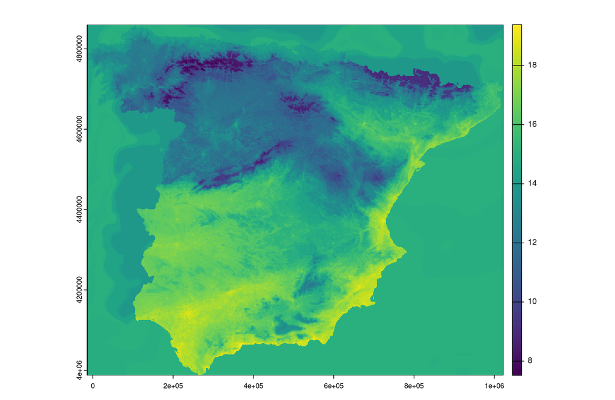

```r
prediction_raster <- terra::predict(predictors, rf_fit)
plot(prediction_raster)
```

## 3 Spatial cross-validation

Cross-validation requires to specify how the data is split into folds. Here, we define a non-spatial cross-validation with `rsample::vfold_cv()` and a spatial cross-validation with `spatialsample::spatial_block_cv()`.

**Hide the code**

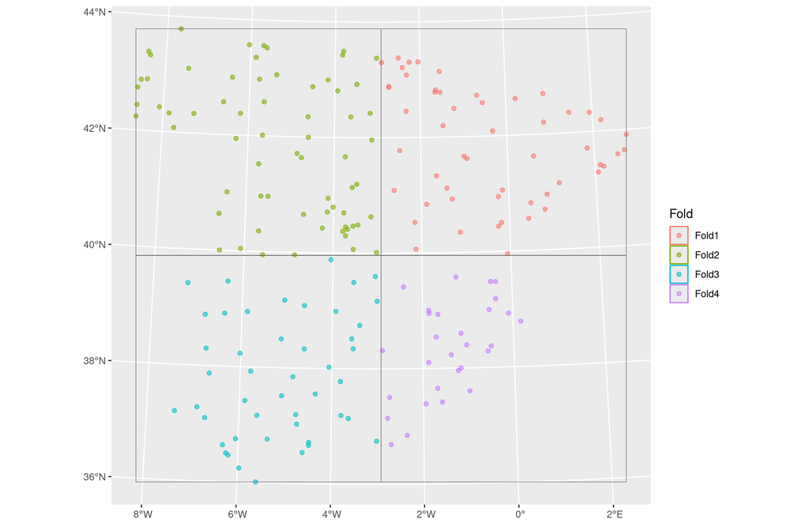

```r
random_folds <- rsample::vfold_cv(trainDat, v = 4)
block_folds <- spatialsample::spatial_block_cv(trainDat, v = 4, n = 2)
spatialsample::autoplot(block_folds)
```

**Hide the code**

```r
# control cross-validation
keep_pred <- tune::control_resamples(save_pred = TRUE, save_workflow = TRUE)
```

Next, we fit the model to the data using cross-validation with `tune::fit_resamples()`.

**Hide the code**

```r
### Cross-validation
rf_random <- tune::fit_resamples(
    workflow,
    resamples = random_folds,
    control = keep_pred
)
rf_spatial <- tune::fit_resamples(
    workflow,
    resamples = block_folds,
    control = keep_pred
)

### get CV metrics
# rf_spatial$.metrics # metrics from each fold
tune::collect_metrics(rf_random)
```

```
# A tibble: 2 × 6
  .metric .estimator  mean     n std_err .config
  <chr>   <chr>      <dbl> <int>   <dbl> <chr>
1 rmse    standard   0.958     4  0.0990 Preprocessor1_Model1
2 rsq     standard   0.898     4  0.0227 Preprocessor1_Model1
```

**Hide the code**

```r
tune::collect_metrics(rf_spatial)
```

```
# A tibble: 2 × 6
  .metric .estimator  mean     n std_err .config
  <chr>   <chr>      <dbl> <int>   <dbl> <chr>
1 rmse    standard   1.35      4  0.314  Preprocessor1_Model1
2 rsq     standard   0.745     4  0.0577 Preprocessor1_Model1
```

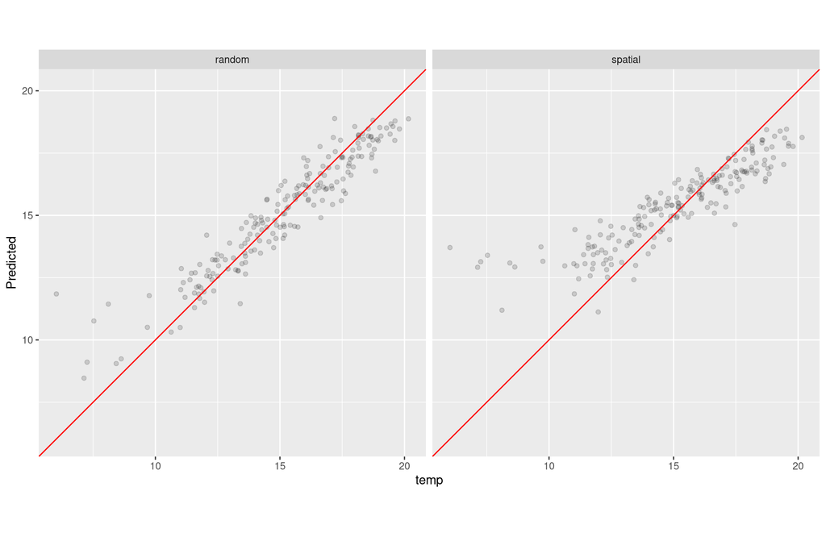

**Note**

Similar to **caret**, we first define folds and a definition of train control. The final model, however, is still stored in a separate object.

## 4 Model tuning: spatial hyperparameter tuning and variable selection

### 4.1 Hyperparameter tuning

Next, we tune the model hyperparameters. For this, we change the workflow to include the tuning specifications by using the `tune()` function inside the model definition and define a grid of hyperparameters to search over. The tuning is done with `tune::tune_grid()`.

**Hide the code**

```r
# mark two parameters for tuning:
rf_model <- parsnip::rand_forest(
    trees = 100,
    mode = "regression",
    mtry = tune(),
    min_n = tune()
) |>
    set_engine("ranger", importance = "impurity")

workflow <- update_model(workflow, rf_model)

# define tune grid:
grid_rf <-
    grid_space_filling(
        mtry(range = c(1, 20)),
        min_n(range = c(2, 10)),
        size = 30
    )

# tune:
rf_tuning <- tune_grid(
    workflow,
    resamples = block_folds,
    grid = grid_rf,
    control = keep_pred
)
```

The results can be extracted with `collect_metrics()` and then visualized.

**Hide the code**

```r
rf_tuning |>
    collect_metrics()
```

```
# A tibble: 60 × 8
    mtry min_n .metric .estimator  mean     n std_err .config
   <int> <int> <chr>   <chr>      <dbl> <int>   <dbl> <chr>
 1     1     5 rmse    standard   1.88      4  0.278  Preprocessor1_Model01
 2     1     5 rsq     standard   0.610     4  0.100  Preprocessor1_Model01
 3     1     9 rmse    standard   1.96      4  0.322  Preprocessor1_Model02
 4     1     9 rsq     standard   0.603     4  0.125  Preprocessor1_Model02
 5     2     4 rmse    standard   1.71      4  0.328  Preprocessor1_Model03
 6     2     4 rsq     standard   0.639     4  0.0833 Preprocessor1_Model03
 7     2     2 rmse    standard   1.59      4  0.263  Preprocessor1_Model04
 8     2     2 rsq     standard   0.679     4  0.0917 Preprocessor1_Model04
 9     3     7 rmse    standard   1.53      4  0.311  Preprocessor1_Model05
10     3     7 rsq     standard   0.712     4  0.0693 Preprocessor1_Model05
# ℹ 50 more rows
```

**Hide the code**

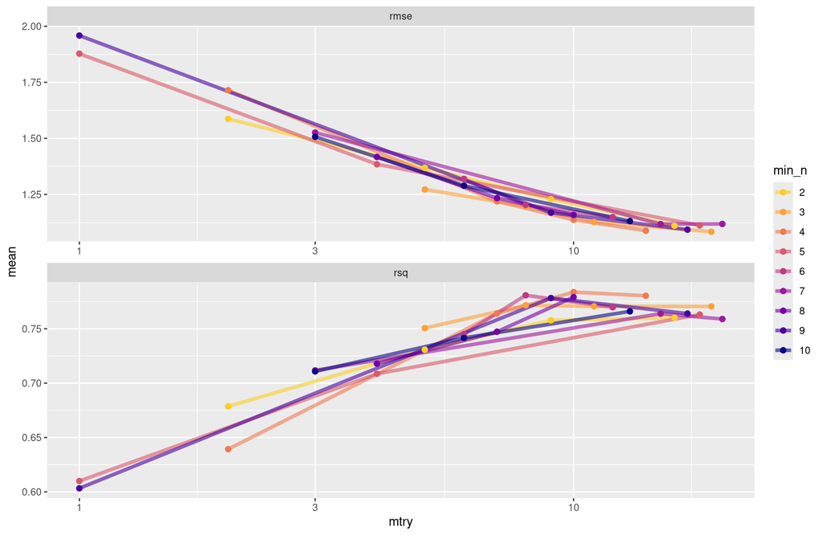

```r
rf_tuning |>
    collect_metrics() |>
    mutate(min_n = factor(min_n)) |>
    ggplot(aes(mtry, mean, color = min_n)) +
    geom_line(linewidth = 1.5, alpha = 0.6) +
    geom_point(size = 2) +
    facet_wrap(~.metric, scales = "free", nrow = 2) +
    scale_x_log10(labels = scales::label_number()) +
    scale_color_viridis_d(option = "plasma", begin = .9, end = 0)
```

Finally, we can extract the best model and use it to get the variable importance and make predictions.

**Hide the code**

```r
finalmodel <- fit_best(rf_tuning)
finalmodel
```

```
══ Workflow [trained] ══════════════════════════════════════════════════════════
Preprocessor: Recipe
Model: rand_forest()

── Preprocessor ────────────────────────────────────────────────────────────────
0 Recipe Steps

── Model ───────────────────────────────────────────────────────────────────────
Ranger result

Call:
 ranger::ranger(x = maybe_data_frame(x), y = y, mtry = min_cols(~19L,      x), num.trees = ~100, min.node.size = min_rows(~3L, x), importance = ~"impurity",      num.threads = 1, verbose = FALSE, seed = sample.int(10^5,          1))

Type:                             Regression
Number of trees:                  100
Sample size:                      195
Number of independent variables:  22
Mtry:                             19
Target node size:                 3
Variable importance mode:         impurity
Splitrule:                        variance
OOB prediction error (MSE):       0.7877882
R squared (OOB):                  0.9011937
```

**Hide the code**

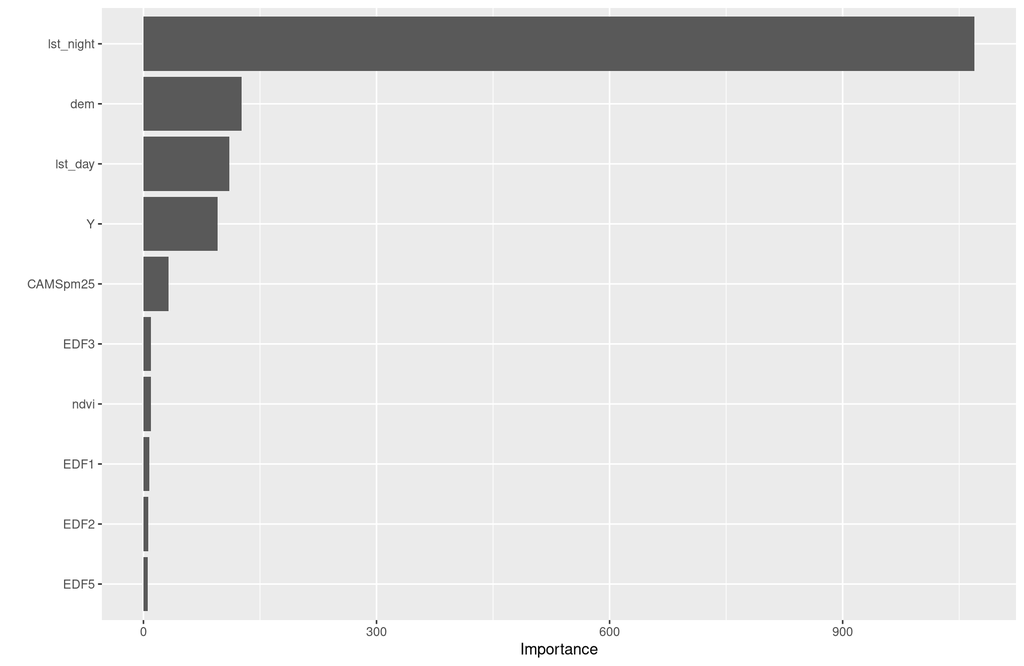

```r
imp <- extract_fit_parsnip(finalmodel) |>
    vip::vip()
imp
```

**Hide the code**

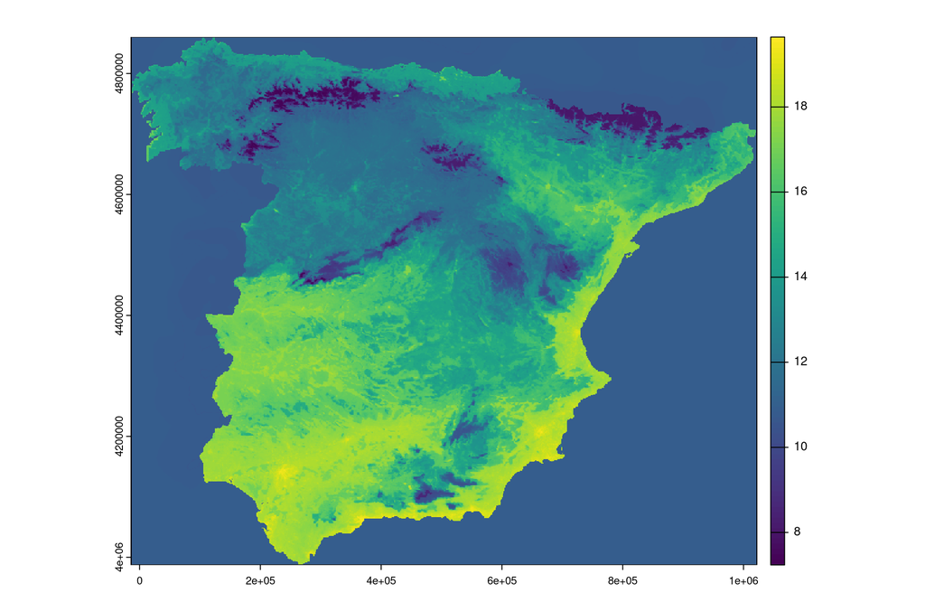

```r
final_pred <- terra::predict(predictors, finalmodel)
plot(final_pred)
```

### 4.2 Feature selection

Still missing: https://stevenpawley.github.io/recipeselectors/

## 5 Area of Applicability, Uncertainties etc

https://applicable.tidymodels.org/, https://docs.ropensci.org/waywiser/

**Hide the code**

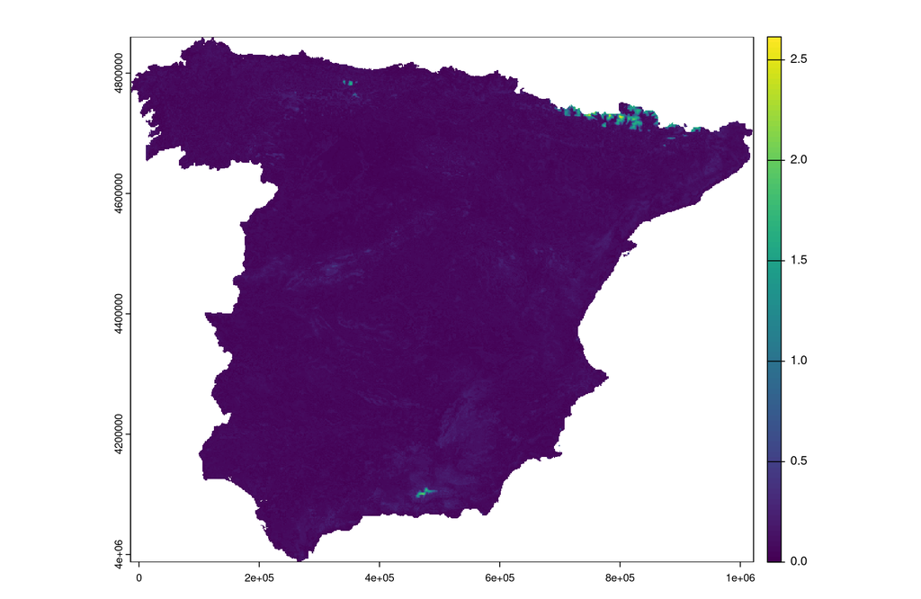

```r
model_aoa <- waywiser::ww_area_of_applicability(
    st_drop_geometry(trainDat[, predictor_names]),
    importance = vip::vi_model(finalmodel)
)

AOA <- terra::predict(predictors, model_aoa)
plot(AOA$di)
```

**Hide the code**

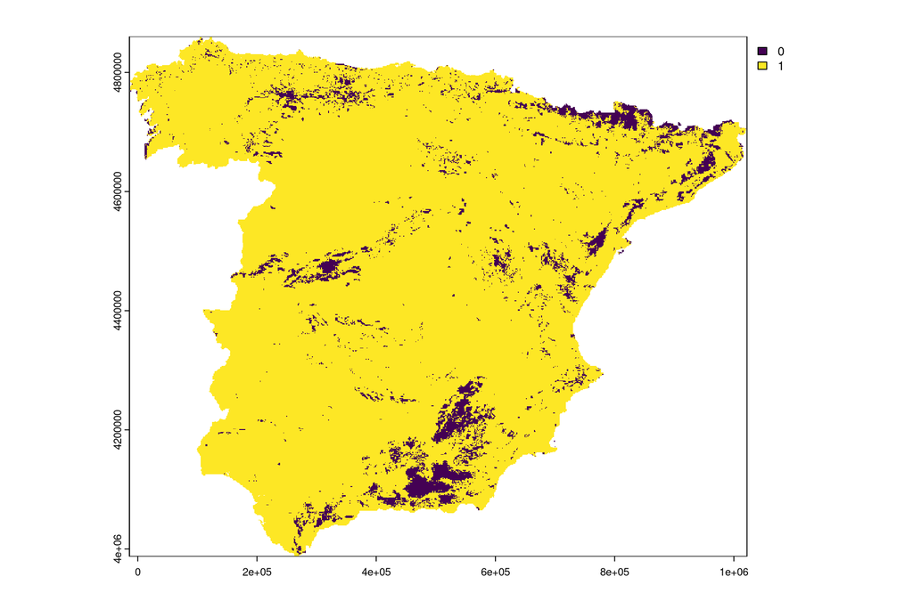

```r
plot(AOA$aoa)
```